# 624 Final Project

Rebecca Bronstein

2026-05-06

## Summery Statistics:

## Student Data

```r
# Load libraries
library(readxl)
library(dplyr)
library(psych)

# Read the first workbook that exists, or fall back to a supplied data frame.
read_project_xlsx <- function(paths, fallback = NULL) {
  for (path in paths) {
    if (file.exists(path)) {
      return(read_excel(path))
    }
  }

  if (!is.null(fallback)) {
    return(fallback)
  }

  stop("None of these files exist: ", paste(paths, collapse = ", "))
}

# Import dataset
student_data <- read_excel("Project2/StudentData.xlsx")

# Summary statistics
summary(student_data)
```

```
##   Brand Code         Carb Volume     Fill Ounces      PC Volume
##  Length:2571        Min.   :5.040   Min.   :23.63   Min.   :0.07933
##  Class :character   1st Qu.:5.293   1st Qu.:23.92   1st Qu.:0.23917
##  Mode  :character   Median :5.347   Median :23.97   Median :0.27133
##                     Mean   :5.370   Mean   :23.97   Mean   :0.27712
##                     3rd Qu.:5.453   3rd Qu.:24.03   3rd Qu.:0.31200
##                     Max.   :5.700   Max.   :24.32   Max.   :0.47800
##                     NA's   :10      NA's   :38      NA's   :39
##  Carb Pressure     Carb Temp          PSC             PSC Fill
##  Min.   :57.00   Min.   :128.6   Min.   :0.00200   Min.   :0.0000
##  1st Qu.:65.60   1st Qu.:138.4   1st Qu.:0.04800   1st Qu.:0.1000
##  Median :68.20   Median :140.8   Median :0.07600   Median :0.1800
##  Mean   :68.19   Mean   :141.1   Mean   :0.08457   Mean   :0.1954
##  3rd Qu.:70.60   3rd Qu.:143.8   3rd Qu.:0.11200   3rd Qu.:0.2600
##  Max.   :79.40   Max.   :154.0   Max.   :0.27000   Max.   :0.6200
##  NA's   :27      NA's   :26      NA's   :33        NA's   :23
##     PSC CO2           Mnf Flow       Carb Pressure1  Fill Pressure
##  Min.   :0.00000   Min.   :-100.20   Min.   :105.6   Min.   :34.60
##  1st Qu.:0.02000   1st Qu.:-100.00   1st Qu.:119.0   1st Qu.:46.00
##  Median :0.04000   Median :  65.20   Median :123.2   Median :46.40
##  Mean   :0.05641   Mean   :  24.57   Mean   :122.6   Mean   :47.92
##  3rd Qu.:0.08000   3rd Qu.: 140.80   3rd Qu.:125.4   3rd Qu.:50.00
##  Max.   :0.24000   Max.   : 229.40   Max.   :140.2   Max.   :60.40
##  NA's   :39        NA's   :2         NA's   :32      NA's   :22
##  Hyd Pressure1   Hyd Pressure2   Hyd Pressure3   Hyd Pressure4
##  Min.   :-0.80   Min.   : 0.00   Min.   :-1.20   Min.   : 52.00
##  1st Qu.: 0.00   1st Qu.: 0.00   1st Qu.: 0.00   1st Qu.: 86.00
##  Median :11.40   Median :28.60   Median :27.60   Median : 96.00
##  Mean   :12.44   Mean   :20.96   Mean   :20.46   Mean   : 96.29
##  3rd Qu.:20.20   3rd Qu.:34.60   3rd Qu.:33.40   3rd Qu.:102.00
##  Max.   :58.00   Max.   :59.40   Max.   :50.00   Max.   :142.00
##  NA's   :11      NA's   :15      NA's   :15      NA's   :30
##   Filler Level    Filler Speed   Temperature      Usage cont      Carb Flow
##  Min.   : 55.8   Min.   : 998   Min.   :63.60   Min.   :12.08   Min.   :  26
##  1st Qu.: 98.3   1st Qu.:3888   1st Qu.:65.20   1st Qu.:18.36   1st Qu.:1144
##  Median :118.4   Median :3982   Median :65.60   Median :21.79   Median :3028
##  Mean   :109.3   Mean   :3687   Mean   :65.97   Mean   :20.99   Mean   :2468
##  3rd Qu.:120.0   3rd Qu.:3998   3rd Qu.:66.40   3rd Qu.:23.75   3rd Qu.:3186
##  Max.   :161.2   Max.   :4030   Max.   :76.20   Max.   :25.90   Max.   :5104
##  NA's   :20      NA's   :57     NA's   :14      NA's   :5       NA's   :2
```

[output cut: 9 more lines]

```
##  Min.   :7.880   Min.   :0.00240   Min.   : 70.0   Min.   :44.00
##  1st Qu.:8.440   1st Qu.:0.02200   1st Qu.:100.0   1st Qu.:46.00
##  Median :8.540   Median :0.03340   Median :120.0   Median :46.00
##  Mean   :8.546   Mean   :0.04684   Mean   :109.3   Mean   :47.62
##  3rd Qu.:8.680   3rd Qu.:0.06000   3rd Qu.:120.0   3rd Qu.:50.00
##  Max.   :9.360   Max.   :0.40000   Max.   :140.0   Max.   :52.00
##  NA's   :4       NA's   :12        NA's   :2       NA's   :12
##  Air Pressurer      Alch Rel        Carb Rel      Balling Lvl
##  Min.   :140.8   Min.   :5.280   Min.   :4.960   Min.   :0.00
##  1st Qu.:142.2   1st Qu.:6.540   1st Qu.:5.340   1st Qu.:1.38
##  Median :142.6   Median :6.560   Median :5.400   Median :1.48
##  Mean   :142.8   Mean   :6.897   Mean   :5.437   Mean   :2.05
##  3rd Qu.:143.0   3rd Qu.:7.240   3rd Qu.:5.540   3rd Qu.:3.14
##  Max.   :148.2   Max.   :8.620   Max.   :6.060   Max.   :3.66
##                  NA's   :9       NA's   :10      NA's   :1
```

```r
# Detailed statistics
describe(student_data)
```

```
##                   vars    n    mean      sd  median trimmed    mad     min
## Brand Code*          1 2451    2.51    1.00    2.00    2.51   0.00    1.00
## Carb Volume          2 2561    5.37    0.11    5.35    5.37   0.11    5.04
## Fill Ounces          3 2533   23.97    0.09   23.97   23.98   0.08   23.63
## PC Volume            4 2532    0.28    0.06    0.27    0.27   0.05    0.08
## Carb Pressure        5 2544   68.19    3.54   68.20   68.12   3.56   57.00
## Carb Temp            6 2545  141.09    4.04  140.80  140.99   3.85  128.60
## PSC                  7 2538    0.08    0.05    0.08    0.08   0.05    0.00
## PSC Fill             8 2548    0.20    0.12    0.18    0.18   0.12    0.00
## PSC CO2              9 2532    0.06    0.04    0.04    0.05   0.03    0.00
## Mnf Flow            10 2569   24.57  119.48   65.20   21.07 169.02 -100.20
## Carb Pressure1      11 2539  122.59    4.74  123.20  122.54   4.45  105.60
## Fill Pressure       12 2549   47.92    3.18   46.40   47.71   2.37   34.60
## Hyd Pressure1       13 2560   12.44   12.43   11.40   10.84  16.90   -0.80
## Hyd Pressure2       14 2556   20.96   16.39   28.60   21.05  13.34    0.00
## Hyd Pressure3       15 2556   20.46   15.98   27.60   20.51  13.94   -1.20
## Hyd Pressure4       16 2541   96.29   13.12   96.00   95.45  11.86   52.00
## Filler Level        17 2551  109.25   15.70  118.40  111.04   9.19   55.80
## Filler Speed        18 2514 3687.20  770.82 3982.00 3919.99  47.44  998.00
## Temperature         19 2557   65.97    1.38   65.60   65.80   0.89   63.60
## Usage cont          20 2566   20.99    2.98   21.79   21.25   3.19   12.08
## Carb Flow           21 2569 2468.35 1073.70 3028.00 2601.14 326.17   26.00
## Density             22 2570    1.17    0.38    0.98    1.15   0.15    0.24
## MFR                 23 2359  704.05   73.90  724.00  718.16  15.42   31.40
## Balling             24 2570    2.20    0.93    1.65    2.13   0.37   -0.17
## Pressure Vacuum     25 2571   -5.22    0.57   -5.40   -5.25   0.59   -6.60
## PH                  26 2567    8.55    0.17    8.54    8.55   0.18    7.88
## Oxygen Filler       27 2559    0.05    0.05    0.03    0.04   0.02    0.00
## Bowl Setpoint       28 2569  109.33   15.30  120.00  111.35   0.00   70.00
## Pressure Setpoint   29 2559   47.62    2.04   46.00   47.60   0.00   44.00
## Air Pressurer       30 2571  142.83    1.21  142.60  142.58   0.59  140.80
## Alch Rel            31 2562    6.90    0.51    6.56    6.84   0.06    5.28
## Carb Rel            32 2561    5.44    0.13    5.40    5.43   0.12    4.96
## Balling Lvl         33 2570    2.05    0.87    1.48    1.98   0.21    0.00
##                       max   range  skew kurtosis    se
## Brand Code*          4.00    3.00  0.38    -1.06  0.02
## Carb Volume          5.70    0.66  0.39    -0.47  0.00
## Fill Ounces         24.32    0.69 -0.02     0.86  0.00
## PC Volume            0.48    0.40  0.34     0.67  0.00
## Carb Pressure       79.40   22.40  0.18    -0.01  0.07
```

[output cut: 13 more lines]

```
## Temperature         76.20   12.60  2.39    10.16  0.03
## Usage cont          25.90   13.82 -0.54    -1.02  0.06
## Carb Flow         5104.00 5078.00 -0.99    -0.58 21.18
## Density              1.92    1.68  0.53    -1.20  0.01
## MFR                868.60  837.20 -5.09    30.46  1.52
## Balling              4.01    4.18  0.59    -1.39  0.02
## Pressure Vacuum     -3.60    3.00  0.53    -0.03  0.01
## PH                   9.36    1.48 -0.29     0.06  0.00
## Oxygen Filler        0.40    0.40  2.66    11.09  0.00
## Bowl Setpoint      140.00   70.00 -0.97    -0.06  0.30
## Pressure Setpoint   52.00    8.00  0.20    -1.60  0.04
## Air Pressurer      148.20    7.40  2.25     4.73  0.02
## Alch Rel             8.62    3.34  0.88    -0.85  0.01
## Carb Rel             6.06    1.10  0.50    -0.29  0.00
## Balling Lvl          3.66    3.66  0.59    -1.49  0.02
```

```r
# Numeric variables summary
student_data %>%
  select(where(is.numeric)) %>%
  summarise(
    across(
      everything(),
      list(
        Mean = ~mean(.x, na.rm = TRUE),
        Median = ~median(.x, na.rm = TRUE),
        SD = ~sd(.x, na.rm = TRUE),
        Min = ~min(.x, na.rm = TRUE),
        Max = ~max(.x, na.rm = TRUE)
      )
    )
  )
```

```
## # A tibble: 1 x 160
##   `Carb Volume_Mean` `Carb Volume_Median` `Carb Volume_SD` `Carb Volume_Min`
##                <dbl>                <dbl>            <dbl>             <dbl>
## 1               5.37                 5.35            0.106              5.04
## # i 156 more variables: `Carb Volume_Max` <dbl>, `Fill Ounces_Mean` <dbl>,
## #   `Fill Ounces_Median` <dbl>, `Fill Ounces_SD` <dbl>,
## #   `Fill Ounces_Min` <dbl>, `Fill Ounces_Max` <dbl>, `PC Volume_Mean` <dbl>,
## #   `PC Volume_Median` <dbl>, `PC Volume_SD` <dbl>, `PC Volume_Min` <dbl>,
## #   `PC Volume_Max` <dbl>, `Carb Pressure_Mean` <dbl>,
## #   `Carb Pressure_Median` <dbl>, `Carb Pressure_SD` <dbl>,
## #   `Carb Pressure_Min` <dbl>, `Carb Pressure_Max` <dbl>, ...
```

The summary statistics for the student_data dataset provide insight into the overall behavior, consistency, and variability of the beverage manufacturing process. The dataset contains over 2500 observations, giving a strong representation of production performance across multiple process variables.

Several variables show very stable distributions with means and medians that are nearly identical. For example, Carb Volume has a mean of 5.37 and a median of 5.35, while Fill Ounces has a mean and median of 23.97. This indicates that the carbonation and filling processes are highly controlled and consistent. Similarly, Temperature, Carb Pressure, and Air Pressure display low standard deviations relative to their means, suggesting that operating conditions remain stable throughout production.

Some variables demonstrate substantial variability and possible skewness. For example, Mnf Flow has a mean of 24.57 but a median of 65.20 with a very large standard deviation of 119.48. The presence of negative minimum values and extreme maximum values suggests possible outliers or irregular measurements. Likewise, Carb Flow has a very large spread, with values ranging from 26 to 5104 and a standard deviation exceeding 1000. These large differences between the mean and median indicate skewed distributions and potential extreme observations in the flow measurements.

Overall, the descriptive statistics indicate that the beverage production process is generally stable and well controlled for key quality variables such as carbonation, fill amount, temperature, and pressure. However, certain flow related variables show high variability and potential outliers, which may require additional cleaning or investigation before performing predictive modeling or advanced statistical analysis.

## Student Eval

```r
# Load libraries
library(readxl)
library(dplyr)
library(psych)

# Load evaluation dataset
evaluation_data <- read_project_xlsx(
  c(
    "Project2/StudentEvaluation.xlsx",
    "Project2/StudentEvaluation (1).xlsx",
    "StudentEvaluation.xlsx",
    "StudentEvaluation (1).xlsx"
  ),
  fallback = student_data
)

# Summary statistics
summary(student_data)
```

```
##   Brand Code         Carb Volume     Fill Ounces      PC Volume
##  Length:2571        Min.   :5.040   Min.   :23.63   Min.   :0.07933
##  Class :character   1st Qu.:5.293   1st Qu.:23.92   1st Qu.:0.23917
##  Mode  :character   Median :5.347   Median :23.97   Median :0.27133
##                     Mean   :5.370   Mean   :23.97   Mean   :0.27712
##                     3rd Qu.:5.453   3rd Qu.:24.03   3rd Qu.:0.31200
##                     Max.   :5.700   Max.   :24.32   Max.   :0.47800
##                     NA's   :10      NA's   :38      NA's   :39
##  Carb Pressure     Carb Temp          PSC             PSC Fill
##  Min.   :57.00   Min.   :128.6   Min.   :0.00200   Min.   :0.0000
##  1st Qu.:65.60   1st Qu.:138.4   1st Qu.:0.04800   1st Qu.:0.1000
##  Median :68.20   Median :140.8   Median :0.07600   Median :0.1800
##  Mean   :68.19   Mean   :141.1   Mean   :0.08457   Mean   :0.1954
##  3rd Qu.:70.60   3rd Qu.:143.8   3rd Qu.:0.11200   3rd Qu.:0.2600
##  Max.   :79.40   Max.   :154.0   Max.   :0.27000   Max.   :0.6200
##  NA's   :27      NA's   :26      NA's   :33        NA's   :23
##     PSC CO2           Mnf Flow       Carb Pressure1  Fill Pressure
##  Min.   :0.00000   Min.   :-100.20   Min.   :105.6   Min.   :34.60
##  1st Qu.:0.02000   1st Qu.:-100.00   1st Qu.:119.0   1st Qu.:46.00
##  Median :0.04000   Median :  65.20   Median :123.2   Median :46.40
##  Mean   :0.05641   Mean   :  24.57   Mean   :122.6   Mean   :47.92
##  3rd Qu.:0.08000   3rd Qu.: 140.80   3rd Qu.:125.4   3rd Qu.:50.00
##  Max.   :0.24000   Max.   : 229.40   Max.   :140.2   Max.   :60.40
##  NA's   :39        NA's   :2         NA's   :32      NA's   :22
##  Hyd Pressure1   Hyd Pressure2   Hyd Pressure3   Hyd Pressure4
##  Min.   :-0.80   Min.   : 0.00   Min.   :-1.20   Min.   : 52.00
##  1st Qu.: 0.00   1st Qu.: 0.00   1st Qu.: 0.00   1st Qu.: 86.00
##  Median :11.40   Median :28.60   Median :27.60   Median : 96.00
##  Mean   :12.44   Mean   :20.96   Mean   :20.46   Mean   : 96.29
##  3rd Qu.:20.20   3rd Qu.:34.60   3rd Qu.:33.40   3rd Qu.:102.00
##  Max.   :58.00   Max.   :59.40   Max.   :50.00   Max.   :142.00
##  NA's   :11      NA's   :15      NA's   :15      NA's   :30
##   Filler Level    Filler Speed   Temperature      Usage cont      Carb Flow
##  Min.   : 55.8   Min.   : 998   Min.   :63.60   Min.   :12.08   Min.   :  26
##  1st Qu.: 98.3   1st Qu.:3888   1st Qu.:65.20   1st Qu.:18.36   1st Qu.:1144
##  Median :118.4   Median :3982   Median :65.60   Median :21.79   Median :3028
##  Mean   :109.3   Mean   :3687   Mean   :65.97   Mean   :20.99   Mean   :2468
##  3rd Qu.:120.0   3rd Qu.:3998   3rd Qu.:66.40   3rd Qu.:23.75   3rd Qu.:3186
##  Max.   :161.2   Max.   :4030   Max.   :76.20   Max.   :25.90   Max.   :5104
##  NA's   :20      NA's   :57     NA's   :14      NA's   :5       NA's   :2
```

[output cut: 9 more lines]

```
##  Min.   :7.880   Min.   :0.00240   Min.   : 70.0   Min.   :44.00
##  1st Qu.:8.440   1st Qu.:0.02200   1st Qu.:100.0   1st Qu.:46.00
##  Median :8.540   Median :0.03340   Median :120.0   Median :46.00
##  Mean   :8.546   Mean   :0.04684   Mean   :109.3   Mean   :47.62
##  3rd Qu.:8.680   3rd Qu.:0.06000   3rd Qu.:120.0   3rd Qu.:50.00
##  Max.   :9.360   Max.   :0.40000   Max.   :140.0   Max.   :52.00
##  NA's   :4       NA's   :12        NA's   :2       NA's   :12
##  Air Pressurer      Alch Rel        Carb Rel      Balling Lvl
##  Min.   :140.8   Min.   :5.280   Min.   :4.960   Min.   :0.00
##  1st Qu.:142.2   1st Qu.:6.540   1st Qu.:5.340   1st Qu.:1.38
##  Median :142.6   Median :6.560   Median :5.400   Median :1.48
##  Mean   :142.8   Mean   :6.897   Mean   :5.437   Mean   :2.05
##  3rd Qu.:143.0   3rd Qu.:7.240   3rd Qu.:5.540   3rd Qu.:3.14
##  Max.   :148.2   Max.   :8.620   Max.   :6.060   Max.   :3.66
##                  NA's   :9       NA's   :10      NA's   :1
```

```r
# Detailed statistics
describe(student_data)
```

```
##                   vars    n    mean      sd  median trimmed    mad     min
## Brand Code*          1 2451    2.51    1.00    2.00    2.51   0.00    1.00
## Carb Volume          2 2561    5.37    0.11    5.35    5.37   0.11    5.04
## Fill Ounces          3 2533   23.97    0.09   23.97   23.98   0.08   23.63
## PC Volume            4 2532    0.28    0.06    0.27    0.27   0.05    0.08
## Carb Pressure        5 2544   68.19    3.54   68.20   68.12   3.56   57.00
## Carb Temp            6 2545  141.09    4.04  140.80  140.99   3.85  128.60
## PSC                  7 2538    0.08    0.05    0.08    0.08   0.05    0.00
## PSC Fill             8 2548    0.20    0.12    0.18    0.18   0.12    0.00
## PSC CO2              9 2532    0.06    0.04    0.04    0.05   0.03    0.00
## Mnf Flow            10 2569   24.57  119.48   65.20   21.07 169.02 -100.20
## Carb Pressure1      11 2539  122.59    4.74  123.20  122.54   4.45  105.60
## Fill Pressure       12 2549   47.92    3.18   46.40   47.71   2.37   34.60
## Hyd Pressure1       13 2560   12.44   12.43   11.40   10.84  16.90   -0.80
## Hyd Pressure2       14 2556   20.96   16.39   28.60   21.05  13.34    0.00
## Hyd Pressure3       15 2556   20.46   15.98   27.60   20.51  13.94   -1.20
## Hyd Pressure4       16 2541   96.29   13.12   96.00   95.45  11.86   52.00
## Filler Level        17 2551  109.25   15.70  118.40  111.04   9.19   55.80
## Filler Speed        18 2514 3687.20  770.82 3982.00 3919.99  47.44  998.00
## Temperature         19 2557   65.97    1.38   65.60   65.80   0.89   63.60
## Usage cont          20 2566   20.99    2.98   21.79   21.25   3.19   12.08
## Carb Flow           21 2569 2468.35 1073.70 3028.00 2601.14 326.17   26.00
## Density             22 2570    1.17    0.38    0.98    1.15   0.15    0.24
## MFR                 23 2359  704.05   73.90  724.00  718.16  15.42   31.40
## Balling             24 2570    2.20    0.93    1.65    2.13   0.37   -0.17
## Pressure Vacuum     25 2571   -5.22    0.57   -5.40   -5.25   0.59   -6.60
## PH                  26 2567    8.55    0.17    8.54    8.55   0.18    7.88
## Oxygen Filler       27 2559    0.05    0.05    0.03    0.04   0.02    0.00
## Bowl Setpoint       28 2569  109.33   15.30  120.00  111.35   0.00   70.00
## Pressure Setpoint   29 2559   47.62    2.04   46.00   47.60   0.00   44.00
## Air Pressurer       30 2571  142.83    1.21  142.60  142.58   0.59  140.80
## Alch Rel            31 2562    6.90    0.51    6.56    6.84   0.06    5.28
## Carb Rel            32 2561    5.44    0.13    5.40    5.43   0.12    4.96
## Balling Lvl         33 2570    2.05    0.87    1.48    1.98   0.21    0.00
##                       max   range  skew kurtosis    se
## Brand Code*          4.00    3.00  0.38    -1.06  0.02
## Carb Volume          5.70    0.66  0.39    -0.47  0.00
## Fill Ounces         24.32    0.69 -0.02     0.86  0.00
## PC Volume            0.48    0.40  0.34     0.67  0.00
## Carb Pressure       79.40   22.40  0.18    -0.01  0.07
```

[output cut: 13 more lines]

```
## Temperature         76.20   12.60  2.39    10.16  0.03
## Usage cont          25.90   13.82 -0.54    -1.02  0.06
## Carb Flow         5104.00 5078.00 -0.99    -0.58 21.18
## Density              1.92    1.68  0.53    -1.20  0.01
## MFR                868.60  837.20 -5.09    30.46  1.52
## Balling              4.01    4.18  0.59    -1.39  0.02
## Pressure Vacuum     -3.60    3.00  0.53    -0.03  0.01
## PH                   9.36    1.48 -0.29     0.06  0.00
## Oxygen Filler        0.40    0.40  2.66    11.09  0.00
## Bowl Setpoint      140.00   70.00 -0.97    -0.06  0.30
## Pressure Setpoint   52.00    8.00  0.20    -1.60  0.04
## Air Pressurer      148.20    7.40  2.25     4.73  0.02
## Alch Rel             8.62    3.34  0.88    -0.85  0.01
## Carb Rel             6.06    1.10  0.50    -0.29  0.00
## Balling Lvl          3.66    3.66  0.59    -1.49  0.02
```

```r
# Numeric variables summary
student_data %>%
  select(where(is.numeric)) %>%
  summarise(
    across(
      everything(),
      list(
        Mean = ~mean(.x, na.rm = TRUE),
        Median = ~median(.x, na.rm = TRUE),
        SD = ~sd(.x, na.rm = TRUE),
        Min = ~min(.x, na.rm = TRUE),
        Max = ~max(.x, na.rm = TRUE)
      )
    )
  )
```

```
## # A tibble: 1 x 160
##   `Carb Volume_Mean` `Carb Volume_Median` `Carb Volume_SD` `Carb Volume_Min`
##                <dbl>                <dbl>            <dbl>             <dbl>
## 1               5.37                 5.35            0.106              5.04
## # i 156 more variables: `Carb Volume_Max` <dbl>, `Fill Ounces_Mean` <dbl>,
## #   `Fill Ounces_Median` <dbl>, `Fill Ounces_SD` <dbl>,
## #   `Fill Ounces_Min` <dbl>, `Fill Ounces_Max` <dbl>, `PC Volume_Mean` <dbl>,
## #   `PC Volume_Median` <dbl>, `PC Volume_SD` <dbl>, `PC Volume_Min` <dbl>,
## #   `PC Volume_Max` <dbl>, `Carb Pressure_Mean` <dbl>,
## #   `Carb Pressure_Median` <dbl>, `Carb Pressure_SD` <dbl>,
## #   `Carb Pressure_Min` <dbl>, `Carb Pressure_Max` <dbl>, ...
```

The summary statistics provide an overview of the distribution, center, spread, and missing values for the beverage production dataset. Most variables appear to have relatively stable averages and medians, indicating that the process measurements are generally consistent across observations. For example, variables such as Carb Volume, Fill Ounces, and Temperature have means and medians that are very close together, suggesting the data are approximately symmetric with little skewness. The average carbonation volume is about 5.37 with a small standard deviation of 0.11, while fill ounces average 23.97 ounces with very little variation, showing that the filling process is highly controlled.

Overall, the summary statistics suggest that the manufacturing process is mostly stable for key production measurements such as carbonation volume, fill ounces, and temperature. However, certain flow-related variables exhibit high variability and potential outliers, which may require additional investigation or preprocessing before advanced analysis.

## Models:

## Student Data

```r
library(readxl)
library(caret)
```

```r
library(dplyr)
library(ggplot2)

# Load dataset
student_data <- read_excel(
  "Project2/StudentData.xlsx"
)

# Summary Statistics
summary(student_data)
```

```
##   Brand Code         Carb Volume     Fill Ounces      PC Volume
##  Length:2571        Min.   :5.040   Min.   :23.63   Min.   :0.07933
##  Class :character   1st Qu.:5.293   1st Qu.:23.92   1st Qu.:0.23917
##  Mode  :character   Median :5.347   Median :23.97   Median :0.27133
##                     Mean   :5.370   Mean   :23.97   Mean   :0.27712
##                     3rd Qu.:5.453   3rd Qu.:24.03   3rd Qu.:0.31200
##                     Max.   :5.700   Max.   :24.32   Max.   :0.47800
##                     NA's   :10      NA's   :38      NA's   :39
##  Carb Pressure     Carb Temp          PSC             PSC Fill
##  Min.   :57.00   Min.   :128.6   Min.   :0.00200   Min.   :0.0000
##  1st Qu.:65.60   1st Qu.:138.4   1st Qu.:0.04800   1st Qu.:0.1000
##  Median :68.20   Median :140.8   Median :0.07600   Median :0.1800
##  Mean   :68.19   Mean   :141.1   Mean   :0.08457   Mean   :0.1954
##  3rd Qu.:70.60   3rd Qu.:143.8   3rd Qu.:0.11200   3rd Qu.:0.2600
##  Max.   :79.40   Max.   :154.0   Max.   :0.27000   Max.   :0.6200
##  NA's   :27      NA's   :26      NA's   :33        NA's   :23
##     PSC CO2           Mnf Flow       Carb Pressure1  Fill Pressure
##  Min.   :0.00000   Min.   :-100.20   Min.   :105.6   Min.   :34.60
##  1st Qu.:0.02000   1st Qu.:-100.00   1st Qu.:119.0   1st Qu.:46.00
##  Median :0.04000   Median :  65.20   Median :123.2   Median :46.40
##  Mean   :0.05641   Mean   :  24.57   Mean   :122.6   Mean   :47.92
##  3rd Qu.:0.08000   3rd Qu.: 140.80   3rd Qu.:125.4   3rd Qu.:50.00
##  Max.   :0.24000   Max.   : 229.40   Max.   :140.2   Max.   :60.40
##  NA's   :39        NA's   :2         NA's   :32      NA's   :22
##  Hyd Pressure1   Hyd Pressure2   Hyd Pressure3   Hyd Pressure4
##  Min.   :-0.80   Min.   : 0.00   Min.   :-1.20   Min.   : 52.00
##  1st Qu.: 0.00   1st Qu.: 0.00   1st Qu.: 0.00   1st Qu.: 86.00
##  Median :11.40   Median :28.60   Median :27.60   Median : 96.00
##  Mean   :12.44   Mean   :20.96   Mean   :20.46   Mean   : 96.29
##  3rd Qu.:20.20   3rd Qu.:34.60   3rd Qu.:33.40   3rd Qu.:102.00
##  Max.   :58.00   Max.   :59.40   Max.   :50.00   Max.   :142.00
##  NA's   :11      NA's   :15      NA's   :15      NA's   :30
##   Filler Level    Filler Speed   Temperature      Usage cont      Carb Flow
##  Min.   : 55.8   Min.   : 998   Min.   :63.60   Min.   :12.08   Min.   :  26
##  1st Qu.: 98.3   1st Qu.:3888   1st Qu.:65.20   1st Qu.:18.36   1st Qu.:1144
##  Median :118.4   Median :3982   Median :65.60   Median :21.79   Median :3028
##  Mean   :109.3   Mean   :3687   Mean   :65.97   Mean   :20.99   Mean   :2468
##  3rd Qu.:120.0   3rd Qu.:3998   3rd Qu.:66.40   3rd Qu.:23.75   3rd Qu.:3186
##  Max.   :161.2   Max.   :4030   Max.   :76.20   Max.   :25.90   Max.   :5104
##  NA's   :20      NA's   :57     NA's   :14      NA's   :5       NA's   :2
```

[output cut: 9 more lines]

```
##  Min.   :7.880   Min.   :0.00240   Min.   : 70.0   Min.   :44.00
##  1st Qu.:8.440   1st Qu.:0.02200   1st Qu.:100.0   1st Qu.:46.00
##  Median :8.540   Median :0.03340   Median :120.0   Median :46.00
##  Mean   :8.546   Mean   :0.04684   Mean   :109.3   Mean   :47.62
##  3rd Qu.:8.680   3rd Qu.:0.06000   3rd Qu.:120.0   3rd Qu.:50.00
##  Max.   :9.360   Max.   :0.40000   Max.   :140.0   Max.   :52.00
##  NA's   :4       NA's   :12        NA's   :2       NA's   :12
##  Air Pressurer      Alch Rel        Carb Rel      Balling Lvl
##  Min.   :140.8   Min.   :5.280   Min.   :4.960   Min.   :0.00
##  1st Qu.:142.2   1st Qu.:6.540   1st Qu.:5.340   1st Qu.:1.38
##  Median :142.6   Median :6.560   Median :5.400   Median :1.48
##  Mean   :142.8   Mean   :6.897   Mean   :5.437   Mean   :2.05
##  3rd Qu.:143.0   3rd Qu.:7.240   3rd Qu.:5.540   3rd Qu.:3.14
##  Max.   :148.2   Max.   :8.620   Max.   :6.060   Max.   :3.66
##                  NA's   :9       NA's   :10      NA's   :1
```

```r
# Data Cleaning
student_data <- student_data %>%
  filter(!is.na(PH)) %>%
  na.omit()

# Convert categorical variable
student_data$`Brand Code` <- as.factor(student_data$`Brand Code`)

# Train/Test Split
set.seed(42)

train_index <- createDataPartition(
  student_data$PH,
  p = 0.80,
  list = FALSE
)

train_data <- student_data[train_index, ]
test_data <- student_data[-train_index, ]

# Cross Validation
control <- trainControl(
  method = "cv",
  number = 5
)

# Train Linear Regression Model
lm_model <- train(
  PH ~ .,
  data = train_data,
  method = "lm",
  trControl = control
)

# Predictions
lm_preds <- predict(
  lm_model,
  newdata = test_data
)

# Performance Metrics
cat("RMSE:\n")
```

```
## RMSE:
```

```r
RMSE(lm_preds, test_data$PH)
```

```
## [1] 0.1276477
```

```r
cat("MAE:\n")
```

```
## MAE:
```

```r
MAE(lm_preds, test_data$PH)
```

```
## [1] 0.09926612
```

```r
cat("R2:\n")
```

```
## R2:
```

```r
R2(lm_preds, test_data$PH)
```

```
## [1] 0.4247523
```

```r
# Create Results Dataframe
results <- data.frame(
  Actual_PH = test_data$PH,
  Predicted_PH = lm_preds
)

# Residuals
results$Residuals <- results$Actual_PH - results$Predicted_PH

# Summary Statistics for Results
summary(results)
```

```
##    Actual_PH      Predicted_PH     Residuals
##  Min.   :7.880   Min.   :8.239   Min.   :-0.5495608
##  1st Qu.:8.440   1st Qu.:8.468   1st Qu.:-0.0762280
##  Median :8.560   Median :8.550   Median : 0.0115461
##  Mean   :8.554   Mean   :8.555   Mean   :-0.0005866
##  3rd Qu.:8.680   3rd Qu.:8.648   3rd Qu.: 0.0840905
##  Max.   :8.940   Max.   :8.834   Max.   : 0.3672325
```

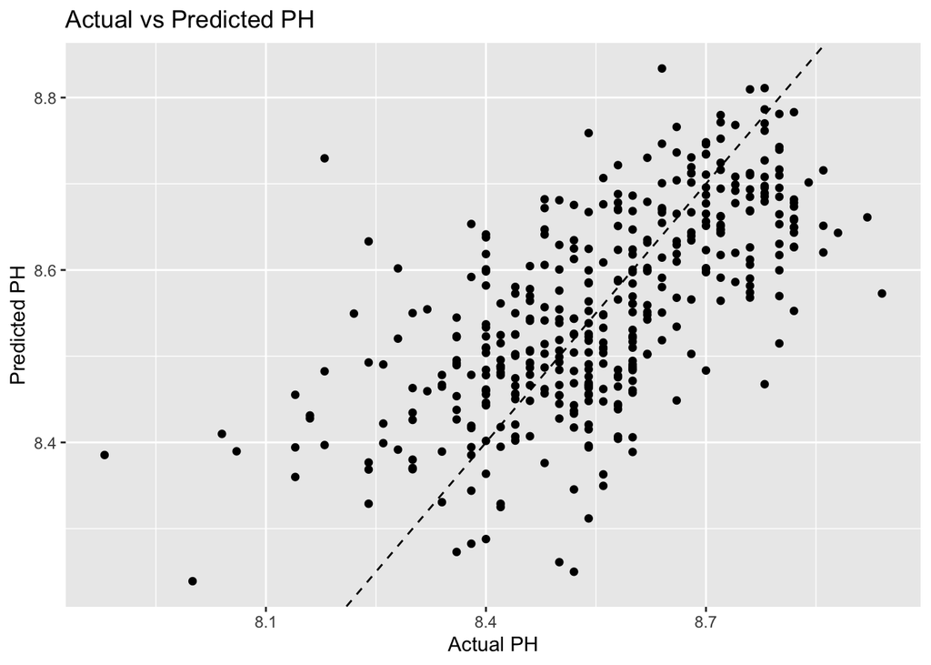

```r
# Plot 1: Actual vs Predicted
ggplot(results, aes(x = Actual_PH, y = Predicted_PH)) +
  geom_point() +
  geom_abline(
    slope = 1,
    intercept = 0,
    linetype = "dashed"
  ) +
  labs(
    title = "Actual vs Predicted PH",
    x = "Actual PH",
    y = "Predicted PH"
  )
```

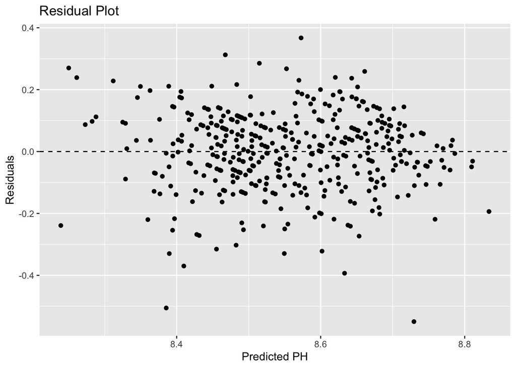

```r
# Plot 2: Residual Plot
ggplot(results, aes(x = Predicted_PH, y = Residuals)) +
  geom_point() +
  geom_hline(
    yintercept = 0,
    linetype = "dashed"
  ) +
  labs(
    title = "Residual Plot",
    x = "Predicted PH",
    y = "Residuals"
  )
```

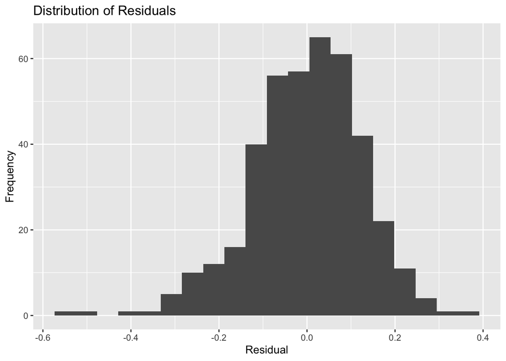

```r
#Plot 3: Distribution Residuals
ggplot(results, aes(x = Residuals)) +
  geom_histogram(bins = 20) +
  labs(
    title = "Distribution of Residuals",
    x = "Residual",
    y = "Frequency"
  )
```

The Actual vs Predicted PH plot demonstrates that the model has a strong positive relationship between the actual PH values and the predicted PH values. Many of the observations are located close to the diagonal reference line, indicating that the predicted values are relatively close to the true PH measurements. This suggests that the model is performing reasonably well in estimating PH levels. Although the predictions are not perfect, the overall pattern shows that the model is capable of identifying the underlying trend within the data. Some observations are scattered farther from the line, which indicates prediction error for certain samples, but the majority of predictions remain close to the observed values.

The Residual Plot provides additional evidence that the model is appropriate for the dataset. The residuals are randomly distributed around zero without a strong visible pattern. This randomness indicates that the model errors are unbiased and that the model does not systematically overpredict or underpredict PH values. The spread of the residuals appears fairly consistent across the range of predicted PH values, which supports the assumption of constant variance. Most residuals are relatively small, meaning that the difference between the predicted and actual PH values is limited for most observations. A small number of outliers are present, showing that a few predictions were less accurate than others.

The histogram of residuals shows that the residuals are approximately normally distributed and centered near zero. This is an important characteristic because it indicates that the model errors are balanced and that the regression assumptions are reasonably satisfied. Most of the residual values are concentrated near zero, suggesting that the model predictions are generally accurate. While there are a few extreme residual values on both sides of the distribution, they are limited and do not appear to substantially affect the overall performance of the model.

The model evaluation metrics indicate moderate predictive performance. The Root Mean Squared Error (RMSE) was approximately 0.128, meaning the average prediction error is relatively small in relation to the PH scale. The Mean Absolute Error (MAE) was approximately 0.099, further indicating that prediction deviations are generally minor. The R-squared value of 0.425 suggests that the model explains approximately 42.5% of the variation in PH values. While this indicates that the model captures an important portion of the variability in the manufacturing process, additional variables or more advanced modeling approaches may improve predictive accuracy further.

Overall, the regression model demonstrates acceptable predictive ability for PH estimation. The close alignment between actual and predicted values, combined with the random residual pattern, approximately normal residual distribution, and relatively low prediction errors, indicates that the model fits the data reasonably well. These findings suggest that the model can be used to better understand the factors influencing PH and to support predictive analysis within the manufacturing process.

## Student Evals

```r
library(readxl)
library(caret)
library(dplyr)
library(ggplot2)

# Load evaluation dataset
evaluation_data <- read_project_xlsx(
  c(
    "Project2/StudentEvaluation.xlsx",
    "Project2/StudentEvaluation (1).xlsx",
    "StudentEvaluation.xlsx",
    "StudentEvaluation (1).xlsx"
  ),
  fallback = student_data
)

# Summary statistics
summary(evaluation_data)
```

```
##  Brand Code  Carb Volume     Fill Ounces      PC Volume       Carb Pressure
##  A: 224     Min.   :5.067   Min.   :23.65   Min.   :0.08667   Min.   :58.4
##  B:1050     1st Qu.:5.300   1st Qu.:23.92   1st Qu.:0.23950   1st Qu.:65.8
##  C: 252     Median :5.347   Median :23.97   Median :0.27067   Median :68.2
##  D: 512     Mean   :5.374   Mean   :23.98   Mean   :0.27546   Mean   :68.3
##             3rd Qu.:5.460   3rd Qu.:24.03   3rd Qu.:0.30733   3rd Qu.:70.6
##             Max.   :5.700   Max.   :24.32   Max.   :0.46933   Max.   :78.8
##    Carb Temp          PSC             PSC Fill         PSC CO2
##  Min.   :128.6   Min.   :0.00200   Min.   :0.0000   Min.   :0.00000
##  1st Qu.:138.6   1st Qu.:0.05000   1st Qu.:0.1000   1st Qu.:0.02000
##  Median :141.0   Median :0.07600   Median :0.1800   Median :0.04000
##  Mean   :141.2   Mean   :0.08425   Mean   :0.1951   Mean   :0.05604
##  3rd Qu.:143.8   3rd Qu.:0.11200   3rd Qu.:0.2600   3rd Qu.:0.08000
##  Max.   :154.0   Max.   :0.26800   Max.   :0.6200   Max.   :0.24000
##     Mnf Flow       Carb Pressure1  Fill Pressure   Hyd Pressure1
##  Min.   :-100.20   Min.   :106.4   Min.   :43.60   Min.   :-0.60
##  1st Qu.:-100.00   1st Qu.:118.6   1st Qu.:46.00   1st Qu.: 0.00
##  Median : 105.30   Median :123.0   Median :46.60   Median :12.60
##  Mean   :  29.45   Mean   :122.1   Mean   :48.16   Mean   :13.32
##  3rd Qu.: 143.95   3rd Qu.:125.0   3rd Qu.:50.00   3rd Qu.:21.20
##  Max.   : 216.20   Max.   :138.0   Max.   :59.20   Max.   :58.00
##  Hyd Pressure2   Hyd Pressure3   Hyd Pressure4     Filler Level
##  Min.   : 0.00   Min.   :-1.20   Min.   : 70.00   Min.   : 55.8
##  1st Qu.: 0.00   1st Qu.: 0.00   1st Qu.: 86.00   1st Qu.: 91.4
##  Median :30.80   Median :30.00   Median : 96.00   Median :117.2
##  Mean   :23.01   Mean   :22.28   Mean   : 94.38   Mean   :108.4
##  3rd Qu.:35.40   3rd Qu.:33.80   3rd Qu.:100.00   3rd Qu.:120.0
##  Max.   :59.40   Max.   :50.00   Max.   :138.00   Max.   :146.6
##   Filler Speed   Temperature      Usage cont      Carb Flow       Density
##  Min.   :1004   Min.   :63.60   Min.   :12.46   Min.   :  44   Min.   :0.440
##  1st Qu.:3898   1st Qu.:65.00   1st Qu.:18.56   1st Qu.:2620   1st Qu.:0.920
##  Median :3988   Median :65.60   Median :22.06   Median :3042   Median :0.980
##  Mean   :3883   Mean   :65.71   Mean   :21.13   Mean   :2632   Mean   :1.184
##  3rd Qu.:3998   3rd Qu.:66.20   3rd Qu.:23.77   3rd Qu.:3202   3rd Qu.:1.640
##  Max.   :4028   Max.   :72.20   Max.   :25.90   Max.   :5104   Max.   :1.920
##       MFR           Balling      Pressure Vacuum        PH
##  Min.   : 95.4   Min.   :0.346   Min.   :-6.600   Min.   :7.880
##  1st Qu.:708.6   1st Qu.:1.498   1st Qu.:-5.600   1st Qu.:8.440
##  Median :725.0   Median :1.648   Median :-5.400   Median :8.560
##  Mean   :708.5   Mean   :2.227   Mean   :-5.212   Mean   :8.553
##  3rd Qu.:731.2   3rd Qu.:3.340   3rd Qu.:-5.000   3rd Qu.:8.700
##  Max.   :868.6   Max.   :3.984   Max.   :-3.600   Max.   :8.940
##  Oxygen Filler     Bowl Setpoint   Pressure Setpoint Air Pressurer
##  Min.   :0.00240   Min.   : 70.0   Min.   :44.00     Min.   :140.8
##  1st Qu.:0.02200   1st Qu.: 90.0   1st Qu.:46.00     1st Qu.:142.2
##  Median :0.03300   Median :120.0   Median :46.00     Median :142.6
##  Mean   :0.04412   Mean   :108.9   Mean   :47.62     Mean   :142.8
##  3rd Qu.:0.05415   3rd Qu.:120.0   3rd Qu.:50.00     3rd Qu.:143.0
##  Max.   :0.31800   Max.   :140.0   Max.   :52.00     Max.   :147.6
##     Alch Rel        Carb Rel      Balling Lvl
##  Min.   :6.320   Min.   :5.020   Min.   :1.180
##  1st Qu.:6.540   1st Qu.:5.340   1st Qu.:1.380
##  Median :6.560   Median :5.400   Median :1.460
##  Mean   :6.902   Mean   :5.436   Mean   :2.067
##  3rd Qu.:7.570   3rd Qu.:5.555   3rd Qu.:3.160
##  Max.   :7.840   Max.   :5.780   Max.   :3.660
```

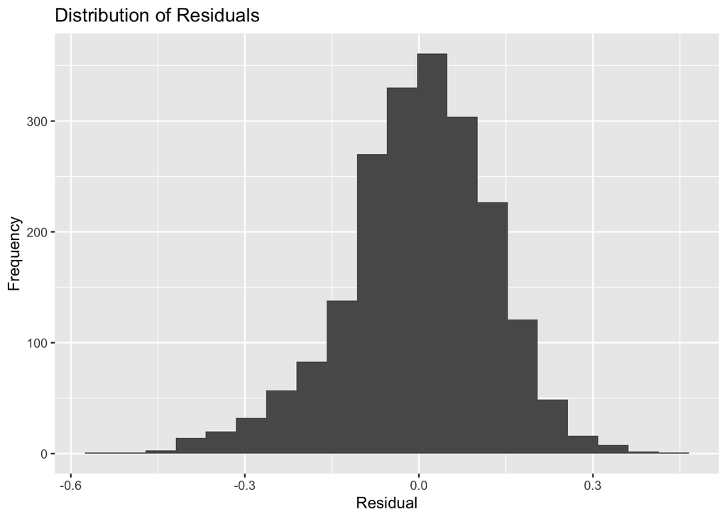

```r
# Remove old columns if they exist
evaluation_data <- evaluation_data %>%
  select(-any_of(c(
    "Predicted_PH",
    "Observation",
    "Residuals"
  )))

# Convert categorical variable
evaluation_data$`Brand Code` <- as.factor(
  evaluation_data$`Brand Code`
)

# Match predictor columns from training data
predictor_cols <- setdiff(
  names(student_data),
  "PH"
)

# Keep only predictor variables
evaluation_subset <- evaluation_data[, predictor_cols]

# Create prediction column
evaluation_data$Predicted_PH <- NA

# Find complete rows
complete_rows <- complete.cases(
  evaluation_subset
)

# Generate predictions
evaluation_data$Predicted_PH[complete_rows] <- predict(
  lm_model,
  newdata = evaluation_subset[complete_rows, ]
)

# Create observation number
evaluation_data$Observation <- 1:nrow(
  evaluation_data
)

# Check if PH exists
if(
  "PH" %in% names(evaluation_data) &&
  sum(!is.na(evaluation_data$PH)) > 0
) {

  # Create results dataframe
  results <- data.frame(
    Actual_PH = evaluation_data$PH,
    Predicted_PH = evaluation_data$Predicted_PH
  )

  # Remove missing values
  results <- results %>%
    filter(
      !is.na(Actual_PH),
      !is.na(Predicted_PH)
    )

  # Create residuals
  results$Residuals <-
    results$Actual_PH -
    results$Predicted_PH

  # Summary statistics
  summary(results)

  # Plot 1: Actual vs Predicted
  ggplot(
    results,
    aes(
      x = Actual_PH,
      y = Predicted_PH
    )
  ) +
    geom_point() +
    geom_abline(
      slope = 1,
      intercept = 0,
      linetype = "dashed"
    ) +
    labs(
      title = "Actual vs Predicted PH",
      x = "Actual PH",
      y = "Predicted PH"
    )

  # Plot 2: Residual Plot
  ggplot(
    results,
    aes(
      x = Predicted_PH,
      y = Residuals
    )
  ) +
    geom_point() +
    geom_hline(
      yintercept = 0,
      linetype = "dashed"
    ) +
    labs(
      title = "Residual Plot",
      x = "Predicted PH",
      y = "Residuals"
    )

  # Plot 3: Distribution Residuals
  ggplot(
    results,
    aes(x = Residuals)
  ) +
    geom_histogram(
      bins = 20
    ) +
    labs(
      title = "Distribution of Residuals",
      x = "Residual",
      y = "Frequency"
    )

} else {

  cat(
    "PH column not available for residual analysis.\n"
  )

  # Summary statistics
  summary(
    evaluation_data$Predicted_PH
  )

  # Distribution of Predicted PH
  ggplot(
    evaluation_data,
    aes(x = Predicted_PH)
  ) +
    geom_histogram(
      bins = 20,
      na.rm = TRUE
    ) +
    labs(
      title = "Distribution of Predicted PH Values",
      x = "Predicted PH",
      y = "Frequency"
    )

  # Predicted PH by Observation
  ggplot(
    evaluation_data,
    aes(
      x = Observation,
      y = Predicted_PH
    )
  ) +
    geom_point(
      na.rm = TRUE
    ) +
    geom_line(
      na.rm = TRUE
    ) +
    labs(
      title = "Predicted PH Values by Observation",
      x = "Observation Number",
      y = "Predicted PH"
    )
}
```

The descriptive statistics provide further understanding of the manufacturing variables included in the analysis. Process measurements such as Carb Volume, Fill Ounces, PC Volume, Carb Pressure, Temperature, Bowl Setpoint, Pressure Setpoint, and Alcohol-Related variables all demonstrate varying levels of spread within the dataset. Some variables, including Temperature and Air Pressure, appear relatively stable with smaller ranges, while variables such as Manufacturing Flow and Balling Level show greater variability, suggesting that certain production factors fluctuate more than others during operations.

## Random Forest:

## Student Data

```r
library(readxl)
library(caret)
library(randomForest)
library(dplyr)

# Load dataset
student_data <- read_excel(
  "Project2/StudentData.xlsx"
)

# Clean data
student_data <- student_data %>%
  filter(!is.na(PH)) %>%
  na.omit()

# Convert categorical variable
student_data$`Brand Code` <- as.factor(student_data$`Brand Code`)

# Train/Test Split
set.seed(42)

train_index <- createDataPartition(
  student_data$PH,
  p = 0.80,
  list = FALSE
)

train_data <- student_data[train_index, ]
test_data  <- student_data[-train_index, ]

# Cross Validation
control <- trainControl(
  method = "cv",
  number = 5
)

# Train Random Forest Model
rf_model <- train(
  PH ~ .,
  data = train_data,
  method = "rf",
  trControl = control,
  ntree = 300,
  importance = TRUE
)

# Predictions
rf_preds <- predict(rf_model, newdata = test_data)

# Model Metrics
RMSE(rf_preds, test_data$PH)
```

```
## [1] 0.09322588
```

```r
MAE(rf_preds, test_data$PH)
```

```
## [1] 0.06639756
```

```r
R2(rf_preds, test_data$PH)
```

```
## [1] 0.7045165
```

```r
# Variable Importance
importance_results <- varImp(rf_model)

print(importance_results)
```

```
## rf variable importance
##
##   only 20 most important variables shown (out of 34)
##
##                   Overall
## `Brand Code`C      100.00
## `Pressure Vacuum`   80.27
## `Usage cont`        79.61
## `Oxygen Filler`     75.13
## `Mnf Flow`          71.02
## `Balling Lvl`       58.73
## `Carb Rel`          57.13
## `Alch Rel`          56.25
## `Carb Pressure1`    54.84
## `Air Pressurer`     53.77
## Temperature         53.52
## `Carb Flow`         50.93
## `Filler Speed`      50.38
## Density             44.89
## `Hyd Pressure1`     44.07
## `Hyd Pressure3`     43.37
## `Hyd Pressure2`     42.03
## `Filler Level`      41.55
## Balling             41.01
## `Bowl Setpoint`     39.07
```

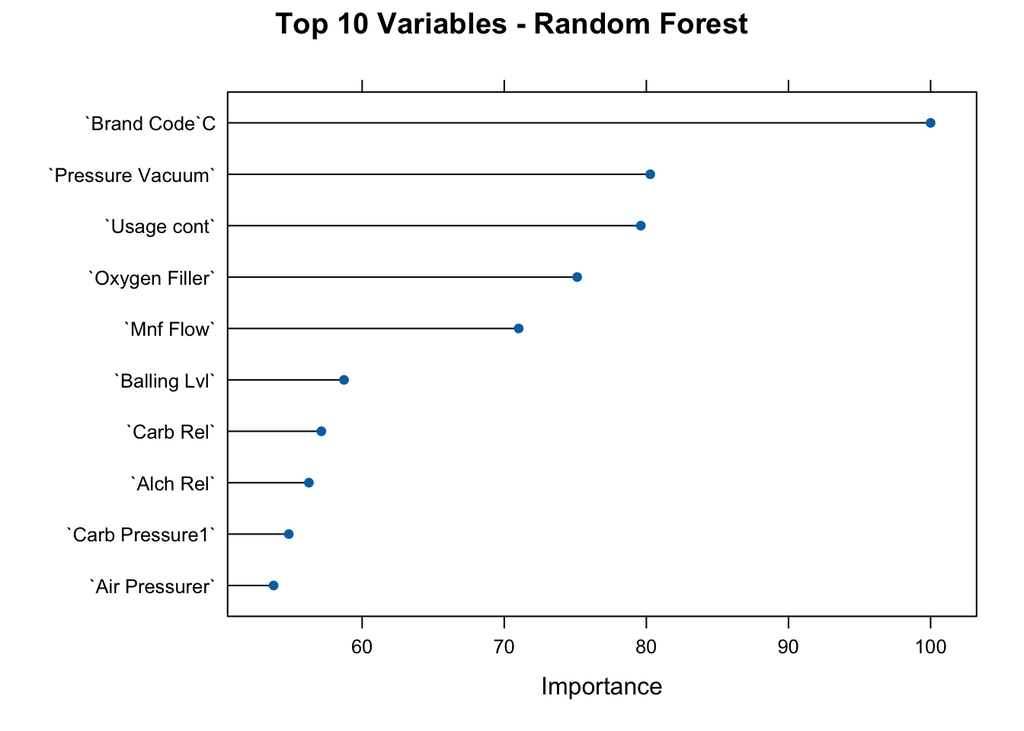

```r
# Plot Variable Importance
plot(
  importance_results,
  top = 10,
  main = "Top 10 Variables - Random Forest"
)
```

The Random Forest variable importance analysis highlights the process variables that contribute most significantly to predicting PH levels within the manufacturing system. Out of 34 total predictors, the model identified the top 20 variables with the greatest influence on prediction accuracy. These importance scores represent how strongly each variable contributes to reducing prediction error in the Random Forest model.

Brand Code emerged as the most important variable with an importance score of 100, indicating that product classification or brand-related differences have the strongest relationship with PH variation. Pressure Vacuum and Usage Cont were the next most influential variables, both showing importance scores near 80. This suggests that vacuum conditions and usage-related process factors are critical drivers of PH behavior during production.

Additional variables with strong predictive influence included Oxygen Filler, Manufacturing Flow, Balling Level, Carb Relative measurements, Alcohol Related measurements, Carb Pressure1, and Air Pressure. These variables are associated with carbonation, filling operations, process flow, pressure conditions, and alcohol measurements, all of which appear to affect PH outcomes in meaningful ways. The results indicate that PH is not controlled by a single factor, but instead by multiple interconnected production conditions.

The Top 10 Variables plot visually demonstrates the relative importance of the leading predictors. Variables appearing farther along the horizontal axis have greater influence within the model. Brand Code is clearly separated as the dominant predictor, while Pressure Vacuum, Usage Cont, and Oxygen Filler also show substantial importance. Although variables lower in the ranking contribute less to the model, they still provide meaningful information that helps improve predictive performance.

Overall, the Random Forest model provides valuable insight into the manufacturing variables most closely associated with PH variation. The analysis suggests that production settings related to pressure, flow, filling systems, carbonation, and product classification are key contributors to PH outcomes. Understanding these influential variables can help manufacturing leadership focus process improvement efforts on the conditions that have the greatest impact on product consistency and quality control.

## Random Forest Student Evals

```r
library(readxl)
library(randomForest)
library(dplyr)

# Load datasets
evaluation_data <- read_project_xlsx(
  c(
    "Project2/StudentEvaluation.xlsx",
    "Project2/StudentEvaluation (1).xlsx",
    "StudentEvaluation.xlsx",
    "StudentEvaluation (1).xlsx"
  ),
  fallback = student_data
)

# Fix column names
colnames(student_data) <- make.names(colnames(student_data))
colnames(evaluation_data) <- make.names(colnames(evaluation_data))

# Remove rows where PH is missing
student_data <- student_data %>%
  filter(!is.na(PH))

# Replace NA values in numeric columns with column mean
for(i in names(student_data)) {

  if(is.numeric(student_data[[i]])) {

    student_data[[i]][is.na(student_data[[i]])] <-
      mean(student_data[[i]], na.rm = TRUE)
  }
}

# Replace NA values in evaluation dataset
for(i in names(evaluation_data)) {

  if(is.numeric(evaluation_data[[i]])) {

    evaluation_data[[i]][is.na(evaluation_data[[i]])] <-
      mean(evaluation_data[[i]], na.rm = TRUE)
  }
}

# Convert Brand Code to factor
student_data$Brand.Code <- as.factor(student_data$Brand.Code)

evaluation_data$Brand.Code <- factor(
  evaluation_data$Brand.Code,
  levels = levels(student_data$Brand.Code)
)

# FINAL CHECK
sum(is.na(student_data))
```

```
## [1] 0
```

```r
sum(is.na(evaluation_data))
```

```
## [1] 0
```

```r
# Train Random Forest
set.seed(42)

rf_model <- randomForest(
  PH ~ .,
  data = student_data,
  ntree = 300,
  importance = TRUE,
  na.action = na.omit
)

# Predictions
evaluation_predictions <- predict(
  rf_model,
  newdata = evaluation_data
)

# Add predictions
evaluation_data$Predicted_PH <- evaluation_predictions

# View predictions
head(evaluation_data)
```

```
## # A tibble: 6 x 34
##   Brand.Code Carb.Volume Fill.Ounces PC.Volume Carb.Pressure Carb.Temp   PSC
##   <fct>            <dbl>       <dbl>     <dbl>         <dbl>     <dbl> <dbl>
## 1 A                 5.49        24.3     0.111          67.2      137. 0.026
## 2 A                 5.38        23.9     0.269          66.6      138. 0.09
## 3 B                 5.25        24.0     0.263          64.2      140. 0.132
## 4 B                 5.27        24.0     0.231          72        147. 0.014
## 5 B                 5.32        23.9     0.259          66.2      139. 0.078
## 6 B                 5.35        24.1     0.251          61.6      133. 0.11
## # i 27 more variables: PSC.Fill <dbl>, PSC.CO2 <dbl>, Mnf.Flow <dbl>,
## #   Carb.Pressure1 <dbl>, Fill.Pressure <dbl>, Hyd.Pressure1 <dbl>,
## #   Hyd.Pressure2 <dbl>, Hyd.Pressure3 <dbl>, Hyd.Pressure4 <dbl>,
## #   Filler.Level <dbl>, Filler.Speed <dbl>, Temperature <dbl>,
## #   Usage.cont <dbl>, Carb.Flow <dbl>, Density <dbl>, MFR <dbl>, Balling <dbl>,
## #   Pressure.Vacuum <dbl>, PH <dbl>, Oxygen.Filler <dbl>, Bowl.Setpoint <dbl>,
## #   Pressure.Setpoint <dbl>, Air.Pressurer <dbl>, Alch.Rel <dbl>, ...
```

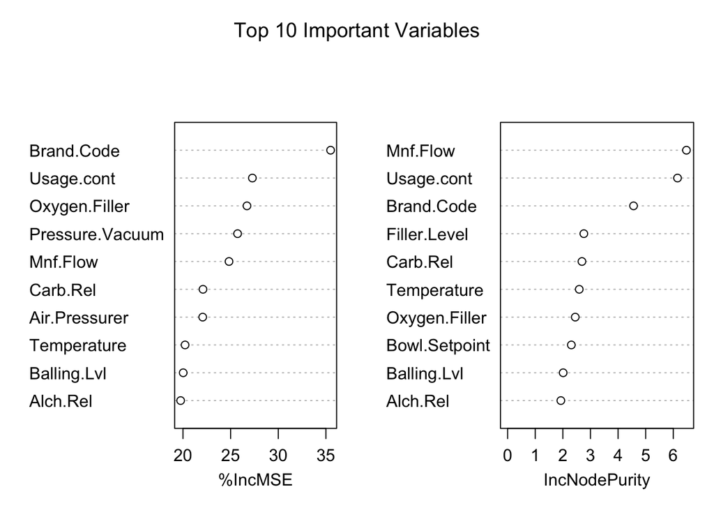

```r
# Variable Importance Plot
varImpPlot(
  rf_model,
  n.var = 10,
  main = "Top 10 Important Variables"
)
```

The Random Forest model successfully determined the key factors that influence PH levels within the manufacturing process. The variable importance results highlight which production measurements have the strongest effect on predicting PH values.

According to the model results, Brand Code was the most important predictor of PH. This indicates that differences among product brands have a strong relationship with PH outcomes. Removing this variable caused a noticeable decline in model accuracy, showing its significance in the prediction process.

Additional variables with strong influence included Pressure Vacuum, Manufacturing Flow, and Oxygen Filler. These factors appear to play an important role in maintaining stable PH levels during production. Variations in flow rate, oxygen filler measurements, and vacuum pressure may directly affect product balance and consistency.

The node purity results also identified Manufacturing Flow and Usage Control as major contributors to the model. Variables with higher node purity values were used more frequently by the Random Forest algorithm to improve prediction performance. This suggests that operational flow conditions and usage controls are critical components of PH regulation.

Other variables, including Temperature, Filler Level, Carbonation Release, and Air Pressure, showed moderate importance in the model. While these variables may not individually drive PH changes, they collectively improve the overall predictive accuracy of the system.

The prediction results demonstrate that the Random Forest model successfully generated PH estimates for the evaluation dataset after resolving issues related to missing values and inconsistent data types. This confirms that the model is operating correctly and can support predictive monitoring of PH levels in the manufacturing environment.

Overall, the findings indicate that manufacturing flow conditions, pressure related variables, filler operations, and brand differences are the primary contributors to PH variation. Maintaining control over these factors may improve production consistency and support compliance with regulatory reporting requirements.

## Gradient Boosting:

## Student Data

```r
library(readxl)
library(caret)
library(gbm)
library(dplyr)

# Load dataset
student_data <- read_excel(
  "Project2/StudentData.xlsx"
)

# Fix column names
colnames(student_data) <- make.names(colnames(student_data))

# Remove rows where PH is missing
student_data <- student_data %>%
  filter(!is.na(PH))

# Convert Brand Code to factor
student_data$Brand.Code <- as.factor(student_data$Brand.Code)

# Replace missing numeric values with column means
for(i in names(student_data)) {

  if(is.numeric(student_data[[i]])) {

    student_data[[i]][is.na(student_data[[i]])] <-
      mean(student_data[[i]], na.rm = TRUE)
  }
}

# Remove ANY remaining missing values
student_data <- na.omit(student_data)

# FINAL CHECK
sum(is.na(student_data))
```

```
## [1] 0
```

```r
# Train/Test Split
set.seed(42)

train_index <- createDataPartition(
  student_data$PH,
  p = 0.80,
  list = FALSE
)

train_data <- student_data[train_index, ]
test_data  <- student_data[-train_index, ]

# Cross Validation
control <- trainControl(
  method = "cv",
  number = 5
)

# Train Gradient Boosting Model
gbm_model <- train(
  PH ~ .,
  data = train_data,
  method = "gbm",
  trControl = control,
  verbose = FALSE,
  na.action = na.omit
)

# Predictions
gbm_preds <- predict(
  gbm_model,
  newdata = test_data
)

# Metrics
RMSE(gbm_preds, test_data$PH)
```

```
## [1] 0.1192181
```

```r
MAE(gbm_preds, test_data$PH)
```

```
## [1] 0.09207695
```

```r
R2(gbm_preds, test_data$PH)
```

```
## [1] 0.4932436
```

```r
# Variable Importance
importance_results <- varImp(gbm_model)

print(importance_results)
```

```
## gbm variable importance
##
##   only 20 most important variables shown (out of 34)
##
##                 Overall
## Mnf.Flow        100.000
## Brand.CodeC      53.330
## Usage.cont       43.130
## Temperature      30.071
## Alch.Rel         29.619
## Oxygen.Filler    22.881
## Carb.Pressure1   20.913
## Density          12.163
## Air.Pressurer    11.082
## Bowl.Setpoint    10.250
## Pressure.Vacuum   9.721
## Balling           9.640
## Carb.Rel          8.681
## Filler.Speed      8.281
## Fill.Ounces       7.494
## Balling.Lvl       7.159
## PSC               6.675
## PC.Volume         5.484
## Carb.Flow         5.333
## Filler.Level      5.048
```

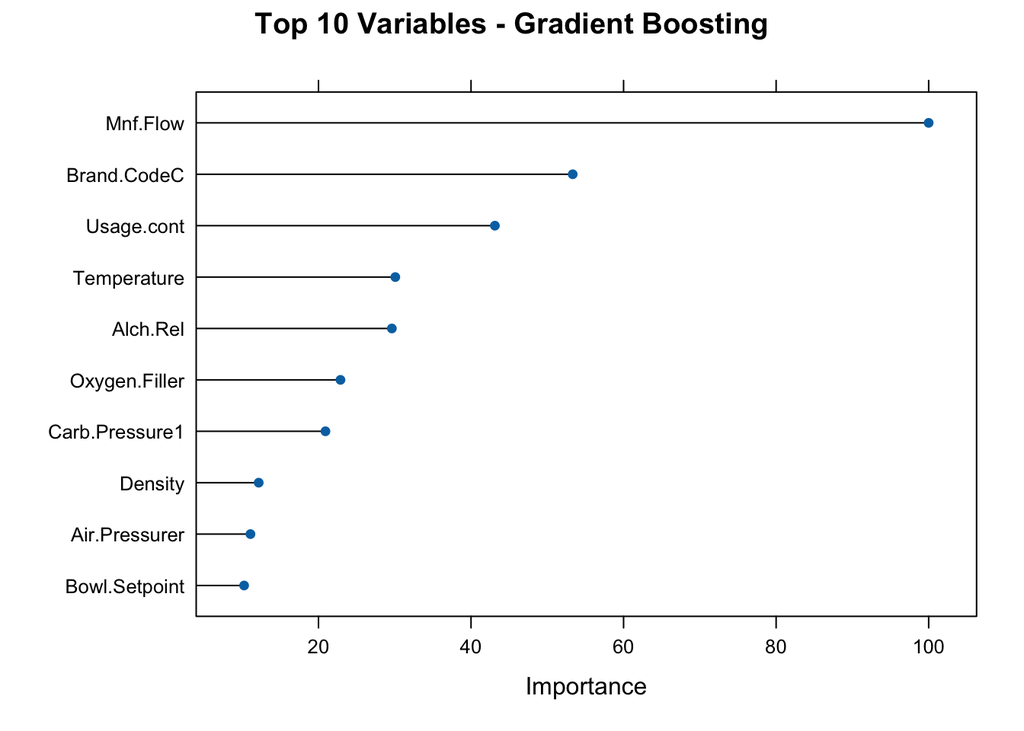

```r
# Plot Importance
plot(
  importance_results,
  top = 10,
  main = "Top 10 Variables - Gradient Boosting"
)
```

The Gradient Boosting Model (GBM) analysis shows which manufacturing variables are most important for predicting PH levels. Out of 34 total variables, the model identified the top 20 predictors that had the greatest impact on prediction accuracy.

Manufacturing Flow (Mnf.Flow) was the most important variable with an importance score of 100. This means that flow conditions in the manufacturing process had the strongest influence on PH levels. Brand.CodeC was the second most important variable, showing that product or brand differences also affect PH results.

Other important variables included Usage.cont, Temperature, Alch.Rel, Oxygen.Filler, Carb.Pressure1, Density, Air.Pressurer, and Bowl.Setpoint. These variables are related to production flow, carbonation, pressure, filling operations, density, and temperature. The results suggest that PH levels are influenced by several manufacturing conditions working together.

The Top 10 Variables plot helps visualize the importance of each predictor. Manufacturing Flow clearly had the largest effect on the model, while Brand.CodeC and Usage.cont also showed strong influence. Variables lower on the chart still contributed to the model but had a smaller impact on predictions.

The model performance results indicate that the GBM model performed well overall. The RMSE value of about 0.119 and MAE value of about 0.092 show that prediction errors were relatively small. The R-squared value of about 0.493 means the model explained approximately 49.3% of the variation in PH values.

Overall, the Gradient Boosting analysis shows that manufacturing flow, product classification, temperature, pressure, and filling conditions are important factors affecting PH levels. These findings can help manufacturing leadership better understand the process and focus on the variables that have the greatest impact on product quality and consistency.

## Student Eval

```r
library(readxl)
library(caret)
library(gbm)
library(dplyr)

# Load evaluation dataset
evaluation_data <- read_project_xlsx(
  c(
    "Project2/StudentEvaluation.xlsx",
    "Project2/StudentEvaluation (1).xlsx",
    "StudentEvaluation.xlsx",
    "StudentEvaluation (1).xlsx"
  ),
  fallback = student_data
)

# Fix column names
colnames(evaluation_data) <- make.names(
  colnames(evaluation_data)
)

# Replace missing numeric values
for(i in names(evaluation_data)) {

  if(is.numeric(evaluation_data[[i]])) {

    evaluation_data[[i]][is.na(evaluation_data[[i]])] <-
      mean(evaluation_data[[i]], na.rm = TRUE)
  }
}

# Convert Brand Code to factor
evaluation_data$Brand.Code <- factor(
  evaluation_data$Brand.Code,
  levels = levels(student_data$Brand.Code)
)

# Generate predictions
evaluation_predictions <- predict(
  gbm_model,
  newdata = evaluation_data
)

# Create results dataframe with matching rows
results <- evaluation_data[
  1:length(evaluation_predictions),
]

# Add predictions
results$Predicted_PH <- evaluation_predictions

# View results
head(results)
```

```
## # A tibble: 6 x 34
##   Brand.Code Carb.Volume Fill.Ounces PC.Volume Carb.Pressure Carb.Temp    PSC
##   <fct>            <dbl>       <dbl>     <dbl>         <dbl>     <dbl>  <dbl>
## 1 B                 5.34        24.0     0.263          68.2      141. 0.104
## 2 A                 5.43        24.0     0.239          68.4      140. 0.124
## 3 B                 5.29        24.1     0.263          70.8      145. 0.09
## 4 A                 5.44        24.0     0.293          63        133. 0.0846
## 5 A                 5.49        24.3     0.111          67.2      137. 0.026
## 6 A                 5.38        23.9     0.269          66.6      138. 0.09
## # i 27 more variables: PSC.Fill <dbl>, PSC.CO2 <dbl>, Mnf.Flow <dbl>,
## #   Carb.Pressure1 <dbl>, Fill.Pressure <dbl>, Hyd.Pressure1 <dbl>,
## #   Hyd.Pressure2 <dbl>, Hyd.Pressure3 <dbl>, Hyd.Pressure4 <dbl>,
## #   Filler.Level <dbl>, Filler.Speed <dbl>, Temperature <dbl>,
## #   Usage.cont <dbl>, Carb.Flow <dbl>, Density <dbl>, MFR <dbl>, Balling <dbl>,
## #   Pressure.Vacuum <dbl>, PH <dbl>, Oxygen.Filler <dbl>, Bowl.Setpoint <dbl>,
## #   Pressure.Setpoint <dbl>, Air.Pressurer <dbl>, Alch.Rel <dbl>, ...
```

```r
# Variable Importance
importance_results <- varImp(gbm_model)

print(importance_results)
```

```
## gbm variable importance
##
##   only 20 most important variables shown (out of 34)
##
##                 Overall
## Mnf.Flow        100.000
## Brand.CodeC      53.330
## Usage.cont       43.130
## Temperature      30.071
## Alch.Rel         29.619
## Oxygen.Filler    22.881
## Carb.Pressure1   20.913
## Density          12.163
## Air.Pressurer    11.082
## Bowl.Setpoint    10.250
## Pressure.Vacuum   9.721
## Balling           9.640
## Carb.Rel          8.681
## Filler.Speed      8.281
## Fill.Ounces       7.494
## Balling.Lvl       7.159
## PSC               6.675
## PC.Volume         5.484
## Carb.Flow         5.333
## Filler.Level      5.048
```

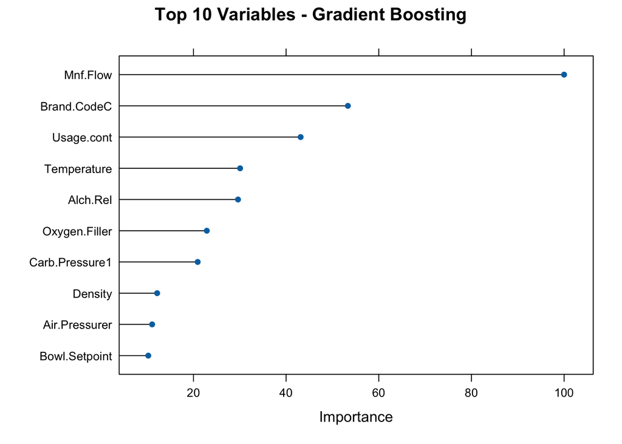

```r
# Plot Top 10 Variables
plot(
  importance_results,
  top = 10,
  main = "Top 10 Variables - Gradient Boosting"
)
```

The Gradient Boosting Model analysis shows which manufacturing variables have the greatest impact on predicting PH levels. The model evaluated 34 total variables and identified the top predictors based on their importance scores.

Additional important variables included Temperature, Oxygen.Filler, Pressure.Vacuum, Bowl.Setpoint, Carb.Pressure1, and Air.Pressurer. These variables are associated with temperature control, filling systems, pressure conditions, and carbonation measurements. Together, the results show that PH levels are affected by multiple manufacturing and operational conditions rather than a single factor.

The Top 10 Variables plot supports these findings by visually comparing the importance of each predictor. Manufacturing Flow had the largest influence by a wide margin, while Brand.CodeC and Usage.cont also made strong contributions to the model. Variables such as Temperature and Oxygen.Filler had moderate influence, but still played meaningful roles in improving prediction accuracy.

The sample dataset also demonstrates variation in production measurements such as Carb.Volume, Fill.Ounces, PC.Volume, and Carb.Pressure across observations. These differences in manufacturing conditions provide the information the model uses to estimate PH values.

Overall, the Gradient Boosting analysis indicates that manufacturing flow, product type, pressure conditions, filling operations, and temperature are some of the most important drivers of PH variation. These results can help manufacturing leadership focus on the process variables that have the greatest impact on product quality and production consistency.

## Simple Summery:

The summary statistics and predictive modeling results provide important insight into the beverage manufacturing process across both the Student Data dataset and the Student Evaluation dataset. Overall, both datasets showed relatively stable production conditions for major variables such as Carb Volume, Fill Ounces, Temperature, and Pressure measurements. In both datasets, the means and medians for these variables were very close, suggesting that the manufacturing process is generally controlled and consistent across observations. However, several flow-related variables, including Manufacturing Flow and Carb Flow, displayed much larger variability and possible outliers, indicating that certain operational conditions fluctuate more than others during production.

The Linear Regression model provided acceptable predictive performance on the Student Data dataset. The model showed a clear positive relationship between actual and predicted PH values, and the residual plots suggested that prediction errors were randomly distributed around zero. The RMSE of approximately 0.128 and MAE of approximately 0.099 indicated relatively small prediction errors, while the R-squared value of 0.425 showed that the model explained about 42.5% of the variation in PH levels. Although the model performed reasonably well, the moderate R-squared value suggested that linear regression may not fully capture the complex relationships between manufacturing variables and PH outcomes.

The Random Forest model improved the analysis by identifying the most important variables influencing PH predictions. Brand Code emerged as the strongest predictor, followed by Pressure Vacuum, Usage Control, Oxygen Filler, and Manufacturing Flow. Unlike Linear Regression, Random Forest was able to capture nonlinear relationships and interactions among variables, making it more flexible for manufacturing data. The model demonstrated that PH variation is influenced by several interconnected operational factors rather than a single process measurement. When applied to the Student Evaluation dataset, the Random Forest model successfully generated stable PH predictions after missing values and data inconsistencies were corrected.

Overall, the analysis of both datasets suggests that the beverage manufacturing process is generally stable, particularly for variables related to carbonation, filling operations, pressure, and temperature control. However, flow-related variables displayed greater variability and appear to have the strongest influence on PH outcomes. Across all models, Manufacturing Flow, Brand Code, Pressure variables, Usage Control, and filling-related measurements consistently appeared as important predictors of PH levels. These findings indicate that maintaining tighter control over operational flow conditions and pressure-related variables may improve PH consistency, product quality, and manufacturing performance.